# Data wrangling WeRateDogs

- The main goal is to wrangle WeRateDogs Twitter data to create interesting and trustworthy analyses and visualizations.
- The dataset that wrangled is the tweet archive of Twitter user @dog_rates, also known as WeRateDogs.

## Steps

- Data wrangling, which consists of:
  - Gathering data
  - Assessing data
  - Cleaning data
- Storing, analyzing, and visualizing our wrangled data
- Reporting on 1) our data wrangling efforts and 2) our data analyses and visualizations

## Data Sources

- Enhanced Twitter Archive
- Additional Data via the Twitter API
- Image Predictions File

### Code

```python
#Import all packages needed
import pandas as pd
import numpy as np
import requests
import tweepy
import json
import matplotlib.pyplot as plt
%matplotlib inline
from tweepy import OAuthHandler
from timeit import default_timer as timer
from datetime import datetime as dt
import zipfile
import seaborn as sns
from IPython.display import Image
```

## Gathering data

```python
#Read CSV file
twitter_archive = pd.read_csv('twitter-archive-enhanced.csv')
```

```python
twitter_archive.head()
```

|  | tweet_id | in_reply_to_status_id | in_reply_to_user_id | timestamp | source | text | retweeted_status_id | retweeted_status_user_id | retweeted_status_timestamp | expanded_urls | rating_numerator | rating_denominator | name | doggo | floofer | pupper | puppo |
| --- | --- | --- | --- | --- | --- | --- | --- | --- | --- | --- | --- | --- | --- | --- | --- | --- | --- |
| 0 | 892420643555336193 | NaN | NaN | 2017-08-01 16:23:56 +0000 | <a href="http://twitter.com/download/iphone" r... | This is Phineas. He's a mystical boy. Only eve... | NaN | NaN | NaN | https://twitter.com/dog_rates/status/892420643... | 13 | 10 | Phineas | None | None | None | None |
| 1 | 892177421306343426 | NaN | NaN | 2017-08-01 00:17:27 +0000 | <a href="http://twitter.com/download/iphone" r... | This is Tilly. She's just checking pup on you.... | NaN | NaN | NaN | https://twitter.com/dog_rates/status/892177421... | 13 | 10 | Tilly | None | None | None | None |
| 2 | 891815181378084864 | NaN | NaN | 2017-07-31 00:18:03 +0000 | <a href="http://twitter.com/download/iphone" r... | This is Archie. He is a rare Norwegian Pouncin... | NaN | NaN | NaN | https://twitter.com/dog_rates/status/891815181... | 12 | 10 | Archie | None | None | None | None |
| 3 | 891689557279858688 | NaN | NaN | 2017-07-30 15:58:51 +0000 | <a href="http://twitter.com/download/iphone" r... | This is Darla. She commenced a snooze mid meal... | NaN | NaN | NaN | https://twitter.com/dog_rates/status/891689557... | 13 | 10 | Darla | None | None | None | None |
| 4 | 891327558926688256 | NaN | NaN | 2017-07-29 16:00:24 +0000 | <a href="http://twitter.com/download/iphone" r... | This is Franklin. He would like you to stop ca... | NaN | NaN | NaN | https://twitter.com/dog_rates/status/891327558... | 12 | 10 | Franklin | None | None | None | None |

```python
twitter_archive.info()
```

```
<class 'pandas.core.frame.DataFrame'>
RangeIndex: 2356 entries, 0 to 2355
Data columns (total 17 columns):
 #   Column                      Non-Null Count  Dtype
---  ------                      --------------  -----
 0   tweet_id                    2356 non-null   int64
 1   in_reply_to_status_id       78 non-null     float64
 2   in_reply_to_user_id         78 non-null     float64
 3   timestamp                   2356 non-null   object
 4   source                      2356 non-null   object
 5   text                        2356 non-null   object
 6   retweeted_status_id         181 non-null    float64
 7   retweeted_status_user_id    181 non-null    float64
 8   retweeted_status_timestamp  181 non-null    object
 9   expanded_urls               2297 non-null   object
 10  rating_numerator            2356 non-null   int64
 11  rating_denominator          2356 non-null   int64
 12  name                        2356 non-null   object
 13  doggo                       2356 non-null   object
 14  floofer                     2356 non-null   object
 15  pupper                      2356 non-null   object
 16  puppo                       2356 non-null   object
dtypes: float64(4), int64(3), object(10)
memory usage: 313.0+ KB
```

```python
# download - tweet image predictions using URL  programatically
url = "https://d17h27t6h515a5.cloudfront.net/topher/2017/August/599fd2ad_image-predictions/image-predictions.tsv"
response = requests.get(url)
# open image-predictions.tsv and write it binary to a file
with open('image-predictions.tsv', mode ='wb') as file:
    file.write(response.content)

#Read TSV file
image_predictions = pd.read_csv('image-predictions.tsv', sep='\t' )
```

```python
image_predictions.head()
```

|  | tweet_id | jpg_url | img_num | p1 | p1_conf | p1_dog | p2 | p2_conf | p2_dog | p3 | p3_conf | p3_dog |
| --- | --- | --- | --- | --- | --- | --- | --- | --- | --- | --- | --- | --- |
| 0 | 666020888022790149 | https://pbs.twimg.com/media/CT4udn0WwAA0aMy.jpg | 1 | Welsh_springer_spaniel | 0.465074 | True | collie | 0.156665 | True | Shetland_sheepdog | 0.061428 | True |
| 1 | 666029285002620928 | https://pbs.twimg.com/media/CT42GRgUYAA5iDo.jpg | 1 | redbone | 0.506826 | True | miniature_pinscher | 0.074192 | True | Rhodesian_ridgeback | 0.072010 | True |
| 2 | 666033412701032449 | https://pbs.twimg.com/media/CT4521TWwAEvMyu.jpg | 1 | German_shepherd | 0.596461 | True | malinois | 0.138584 | True | bloodhound | 0.116197 | True |
| 3 | 666044226329800704 | https://pbs.twimg.com/media/CT5Dr8HUEAA-lEu.jpg | 1 | Rhodesian_ridgeback | 0.408143 | True | redbone | 0.360687 | True | miniature_pinscher | 0.222752 | True |
| 4 | 666049248165822465 | https://pbs.twimg.com/media/CT5IQmsXIAAKY4A.jpg | 1 | miniature_pinscher | 0.560311 | True | Rottweiler | 0.243682 | True | Doberman | 0.154629 | True |

```python
image_predictions.info()
```

```
<class 'pandas.core.frame.DataFrame'>
RangeIndex: 2075 entries, 0 to 2074
Data columns (total 12 columns):
 #   Column    Non-Null Count  Dtype
---  ------    --------------  -----
 0   tweet_id  2075 non-null   int64
 1   jpg_url   2075 non-null   object
 2   img_num   2075 non-null   int64
 3   p1        2075 non-null   object
 4   p1_conf   2075 non-null   float64
 5   p1_dog    2075 non-null   bool
 6   p2        2075 non-null   object
 7   p2_conf   2075 non-null   float64
 8   p2_dog    2075 non-null   bool
 9   p3        2075 non-null   object
 10  p3_conf   2075 non-null   float64
 11  p3_dog    2075 non-null   bool
dtypes: bool(3), float64(3), int64(2), object(4)
memory usage: 152.1+ KB
```

### Use Twitter API and Python's Tweepy library and store each tweet's set of JSON data in tweet_json.txt file.

```python
# Query Twitter API for each tweet in the Twitter archive and save JSON in a text file
# These are hidden to comply with Twitter's API terms and conditions
consumer_key = 'HIDDEN'
consumer_secret = 'HIDDEN'
access_token = 'HIDDEN'
access_secret = 'HIDDEN'

auth = OAuthHandler(consumer_key, consumer_secret)
auth.set_access_token(access_token, access_secret)

api = tweepy.API(auth, wait_on_rate_limit=True)

# NOTE TO STUDENT WITH MOBILE VERIFICATION ISSUES:
# df_1 is a DataFrame with the twitter_archive_enhanced.csv file. You may have to
# change line 17 to match the name of your DataFrame with twitter_archive_enhanced.csv
# NOTE TO REVIEWER: this student had mobile verification issues so the following
# Twitter API code was sent to this student from a Udacity instructor
# Tweet IDs for which to gather additional data via Twitter's API
tweet_ids = twitter_archive.tweet_id.values
len(tweet_ids)

# Query Twitter's API for JSON data for each tweet ID in the Twitter archive
count = 0
fails_dict = {}
start = timer()
# Save each tweet's returned JSON as a new line in a .txt file
with open('tweet_json.txt', 'w') as outfile:
    # This loop will likely take 20-30 minutes to run because of Twitter's rate limit
    for tweet_id in tweet_ids:
        count += 1
        print(str(count) + ": " + str(tweet_id))
        try:
            tweet = api.get_status(tweet_id, tweet_mode='extended')
            print("Success")
            json.dump(tweet._json, outfile)
            outfile.write('\n')
        except tweepy.TweepError as e:
            print("Fail")
            fails_dict[tweet_id] = e
            pass
end = timer()
print(end - start)
print(fails_dict)
```

[output not shown]

[output cut: 4659 more lines]

[output not shown]

```python
# extract the file from the zipfile
with open('tweet-json.zip','rb') as f:
    z_tweets = zipfile.ZipFile(f)
    z_tweets.extractall()

# check for the extracted file
z_tweets.namelist()
```

```
['tweet-json copy']
```

```python
# read the file in DataFrame
with open('tweet-json copy', 'r') as f:
    tweet_json = pd.read_json(f, lines= True, encoding = 'utf-8')

# check the data
tweet_json.head()
```

|  | created_at | id | id_str | full_text | truncated | display_text_range | entities | extended_entities | source | in_reply_to_status_id | ... | favorite_count | favorited | retweeted | possibly_sensitive | possibly_sensitive_appealable | lang | retweeted_status | quoted_status_id | quoted_status_id_str | quoted_status |
| --- | --- | --- | --- | --- | --- | --- | --- | --- | --- | --- | --- | --- | --- | --- | --- | --- | --- | --- | --- | --- | --- |
| 0 | 2017-08-01 16:23:56+00:00 | 892420643555336193 | 892420643555336192 | This is Phineas. He's a mystical boy. Only eve... | False | [0, 85] | {'hashtags': [], 'symbols': [], 'user_mentions... | {'media': [{'id': 892420639486877696, 'id_str'... | <a href="http://twitter.com/download/iphone" r... | NaN | ... | 39467 | False | False | 0.0 | 0.0 | en | NaN | NaN | NaN | NaN |
| 1 | 2017-08-01 00:17:27+00:00 | 892177421306343426 | 892177421306343424 | This is Tilly. She's just checking pup on you.... | False | [0, 138] | {'hashtags': [], 'symbols': [], 'user_mentions... | {'media': [{'id': 892177413194625024, 'id_str'... | <a href="http://twitter.com/download/iphone" r... | NaN | ... | 33819 | False | False | 0.0 | 0.0 | en | NaN | NaN | NaN | NaN |
| 2 | 2017-07-31 00:18:03+00:00 | 891815181378084864 | 891815181378084864 | This is Archie. He is a rare Norwegian Pouncin... | False | [0, 121] | {'hashtags': [], 'symbols': [], 'user_mentions... | {'media': [{'id': 891815175371796480, 'id_str'... | <a href="http://twitter.com/download/iphone" r... | NaN | ... | 25461 | False | False | 0.0 | 0.0 | en | NaN | NaN | NaN | NaN |
| 3 | 2017-07-30 15:58:51+00:00 | 891689557279858688 | 891689557279858688 | This is Darla. She commenced a snooze mid meal... | False | [0, 79] | {'hashtags': [], 'symbols': [], 'user_mentions... | {'media': [{'id': 891689552724799489, 'id_str'... | <a href="http://twitter.com/download/iphone" r... | NaN | ... | 42908 | False | False | 0.0 | 0.0 | en | NaN | NaN | NaN | NaN |
| 4 | 2017-07-29 16:00:24+00:00 | 891327558926688256 | 891327558926688256 | This is Franklin. He would like you to stop ca... | False | [0, 138] | {'hashtags': [{'text': 'BarkWeek', 'indices': ... | {'media': [{'id': 891327551943041024, 'id_str'... | <a href="http://twitter.com/download/iphone" r... | NaN | ... | 41048 | False | False | 0.0 | 0.0 | en | NaN | NaN | NaN | NaN |

5 rows × 31 columns

```python
# check for the columns names
tweet_json.columns
```

```
Index(['created_at', 'id', 'id_str', 'full_text', 'truncated',
       'display_text_range', 'entities', 'extended_entities', 'source',
       'in_reply_to_status_id', 'in_reply_to_status_id_str',
       'in_reply_to_user_id', 'in_reply_to_user_id_str',
       'in_reply_to_screen_name', 'user', 'geo', 'coordinates', 'place',
       'contributors', 'is_quote_status', 'retweet_count', 'favorite_count',
       'favorited', 'retweeted', 'possibly_sensitive',
       'possibly_sensitive_appealable', 'lang', 'retweeted_status',
       'quoted_status_id', 'quoted_status_id_str', 'quoted_status'],
      dtype='object')
```

```python
# select the columns of interest : 'id', 'favorite_count','retweet_count'
tweet_json = tweet_json.loc[:,['id','favorite_count','retweet_count']]

# check for the top 5 rows
tweet_json.head()
```

|  | id | favorite_count | retweet_count |
| --- | --- | --- | --- |
| 0 | 892420643555336193 | 39467 | 8853 |
| 1 | 892177421306343426 | 33819 | 6514 |
| 2 | 891815181378084864 | 25461 | 4328 |
| 3 | 891689557279858688 | 42908 | 8964 |
| 4 | 891327558926688256 | 41048 | 9774 |

## Assessing data

- Visual assessment
- Programmatic assessment
- Three datasets
  - twitter_archive
  - image_predictions
  - tweet_json

#### witter_archive dataset assessment

```python
# display twitter archive
twitter_archive
```

|  | tweet_id | in_reply_to_status_id | in_reply_to_user_id | timestamp | source | text | retweeted_status_id | retweeted_status_user_id | retweeted_status_timestamp | expanded_urls | rating_numerator | rating_denominator | name | doggo | floofer | pupper | puppo |
| --- | --- | --- | --- | --- | --- | --- | --- | --- | --- | --- | --- | --- | --- | --- | --- | --- | --- |
| 0 | 892420643555336193 | NaN | NaN | 2017-08-01 16:23:56 +0000 | <a href="http://twitter.com/download/iphone" r... | This is Phineas. He's a mystical boy. Only eve... | NaN | NaN | NaN | https://twitter.com/dog_rates/status/892420643... | 13 | 10 | Phineas | None | None | None | None |
| 1 | 892177421306343426 | NaN | NaN | 2017-08-01 00:17:27 +0000 | <a href="http://twitter.com/download/iphone" r... | This is Tilly. She's just checking pup on you.... | NaN | NaN | NaN | https://twitter.com/dog_rates/status/892177421... | 13 | 10 | Tilly | None | None | None | None |
| 2 | 891815181378084864 | NaN | NaN | 2017-07-31 00:18:03 +0000 | <a href="http://twitter.com/download/iphone" r... | This is Archie. He is a rare Norwegian Pouncin... | NaN | NaN | NaN | https://twitter.com/dog_rates/status/891815181... | 12 | 10 | Archie | None | None | None | None |
| 3 | 891689557279858688 | NaN | NaN | 2017-07-30 15:58:51 +0000 | <a href="http://twitter.com/download/iphone" r... | This is Darla. She commenced a snooze mid meal... | NaN | NaN | NaN | https://twitter.com/dog_rates/status/891689557... | 13 | 10 | Darla | None | None | None | None |
| 4 | 891327558926688256 | NaN | NaN | 2017-07-29 16:00:24 +0000 | <a href="http://twitter.com/download/iphone" r... | This is Franklin. He would like you to stop ca... | NaN | NaN | NaN | https://twitter.com/dog_rates/status/891327558... | 12 | 10 | Franklin | None | None | None | None |
| ... | ... | ... | ... | ... | ... | ... | ... | ... | ... | ... | ... | ... | ... | ... | ... | ... | ... |
| 2351 | 666049248165822465 | NaN | NaN | 2015-11-16 00:24:50 +0000 | <a href="http://twitter.com/download/iphone" r... | Here we have a 1949 1st generation vulpix. Enj... | NaN | NaN | NaN | https://twitter.com/dog_rates/status/666049248... | 5 | 10 | None | None | None | None | None |
| 2352 | 666044226329800704 | NaN | NaN | 2015-11-16 00:04:52 +0000 | <a href="http://twitter.com/download/iphone" r... | This is a purebred Piers Morgan. Loves to Netf... | NaN | NaN | NaN | https://twitter.com/dog_rates/status/666044226... | 6 | 10 | a | None | None | None | None |
| 2353 | 666033412701032449 | NaN | NaN | 2015-11-15 23:21:54 +0000 | <a href="http://twitter.com/download/iphone" r... | Here is a very happy pup. Big fan of well-main... | NaN | NaN | NaN | https://twitter.com/dog_rates/status/666033412... | 9 | 10 | a | None | None | None | None |
| 2354 | 666029285002620928 | NaN | NaN | 2015-11-15 23:05:30 +0000 | <a href="http://twitter.com/download/iphone" r... | This is a western brown Mitsubishi terrier. Up... | NaN | NaN | NaN | https://twitter.com/dog_rates/status/666029285... | 7 | 10 | a | None | None | None | None |
| 2355 | 666020888022790149 | NaN | NaN | 2015-11-15 22:32:08 +0000 | <a href="http://twitter.com/download/iphone" r... | Here we have a Japanese Irish Setter. Lost eye... | NaN | NaN | NaN | https://twitter.com/dog_rates/status/666020888... | 8 | 10 | None | None | None | None | None |

2356 rows × 17 columns

```python
# data sample
twitter_archive.sample(5)
```

|  | tweet_id | in_reply_to_status_id | in_reply_to_user_id | timestamp | source | text | retweeted_status_id | retweeted_status_user_id | retweeted_status_timestamp | expanded_urls | rating_numerator | rating_denominator | name | doggo | floofer | pupper | puppo |
| --- | --- | --- | --- | --- | --- | --- | --- | --- | --- | --- | --- | --- | --- | --- | --- | --- | --- |
| 436 | 820314633777061888 | NaN | NaN | 2017-01-14 17:00:24 +0000 | <a href="http://twitter.com/download/iphone" r... | We are proud to support @LoveYourMelon on thei... | NaN | NaN | NaN | https://www.loveyourmelon.com/pages/ourstory,h... | 14 | 10 | None | None | None | None | None |
| 631 | 794205286408003585 | NaN | NaN | 2016-11-03 15:51:10 +0000 | <a href="http://twitter.com/download/iphone" r... | This is Laika. She was a space pupper. The fir... | NaN | NaN | NaN | https://twitter.com/dog_rates/status/794205286... | 14 | 10 | Laika | None | None | pupper | None |
| 1596 | 686286779679375361 | NaN | NaN | 2016-01-10 20:41:33 +0000 | <a href="http://vine.co" rel="nofollow">Vine -... | When bae calls your name from across the room.... | NaN | NaN | NaN | https://vine.co/v/iMZx6aDbExn | 12 | 10 | None | None | None | None | None |
| 1547 | 689280876073582592 | NaN | NaN | 2016-01-19 02:59:01 +0000 | <a href="http://twitter.com/download/iphone" r... | This is Herald. He wants you to know he could ... | NaN | NaN | NaN | https://twitter.com/dog_rates/status/689280876... | 10 | 10 | Herald | None | None | None | None |
| 1276 | 709158332880297985 | NaN | NaN | 2016-03-13 23:24:56 +0000 | <a href="http://twitter.com/download/iphone" r... | Meet Rodney. He's a Ukranian Boomchicka. Outsi... | NaN | NaN | NaN | https://twitter.com/dog_rates/status/709158332... | 10 | 10 | Rodney | None | None | None | None |

```python
# twitter_archive data info
twitter_archive.info()
```

```
<class 'pandas.core.frame.DataFrame'>
RangeIndex: 2356 entries, 0 to 2355
Data columns (total 17 columns):
 #   Column                      Non-Null Count  Dtype
---  ------                      --------------  -----
 0   tweet_id                    2356 non-null   int64
 1   in_reply_to_status_id       78 non-null     float64
 2   in_reply_to_user_id         78 non-null     float64
 3   timestamp                   2356 non-null   object
 4   source                      2356 non-null   object
 5   text                        2356 non-null   object
 6   retweeted_status_id         181 non-null    float64
 7   retweeted_status_user_id    181 non-null    float64
 8   retweeted_status_timestamp  181 non-null    object
 9   expanded_urls               2297 non-null   object
 10  rating_numerator            2356 non-null   int64
 11  rating_denominator          2356 non-null   int64
 12  name                        2356 non-null   object
 13  doggo                       2356 non-null   object
 14  floofer                     2356 non-null   object
 15  pupper                      2356 non-null   object
 16  puppo                       2356 non-null   object
dtypes: float64(4), int64(3), object(10)
memory usage: 313.0+ KB
```

```python
# null values
twitter_archive.isnull().sum()
```

```
tweet_id                         0
in_reply_to_status_id         2278
in_reply_to_user_id           2278
timestamp                        0
source                           0
text                             0
retweeted_status_id           2175
retweeted_status_user_id      2175
retweeted_status_timestamp    2175
expanded_urls                   59
rating_numerator                 0
rating_denominator               0
name                             0
doggo                            0
floofer                          0
pupper                           0
puppo                            0
dtype: int64
```

```python
# Find all names that start with a lowercase letter
lowercase_names = []
for row in twitter_archive['name']:
    if row[0].islower() and row not in lowercase_names:
        lowercase_names.append(row)
print(lowercase_names)
```

```
['such', 'a', 'quite', 'not', 'one', 'incredibly', 'mad', 'an', 'very', 'just', 'my', 'his', 'actually', 'getting', 'this', 'unacceptable', 'all', 'old', 'infuriating', 'the', 'by', 'officially', 'life', 'light', 'space']
```

```python
twitter_archive['name'].value_counts()['None']
```

```
745
```

```python
# statistical description of twitter archive
twitter_archive.describe()
```

|  | tweet_id | in_reply_to_status_id | in_reply_to_user_id | retweeted_status_id | retweeted_status_user_id | rating_numerator | rating_denominator |
| --- | --- | --- | --- | --- | --- | --- | --- |
| count | 2.356000e+03 | 7.800000e+01 | 7.800000e+01 | 1.810000e+02 | 1.810000e+02 | 2356.000000 | 2356.000000 |
| mean | 7.427716e+17 | 7.455079e+17 | 2.014171e+16 | 7.720400e+17 | 1.241698e+16 | 13.126486 | 10.455433 |
| std | 6.856705e+16 | 7.582492e+16 | 1.252797e+17 | 6.236928e+16 | 9.599254e+16 | 45.876648 | 6.745237 |
| min | 6.660209e+17 | 6.658147e+17 | 1.185634e+07 | 6.661041e+17 | 7.832140e+05 | 0.000000 | 0.000000 |
| 25% | 6.783989e+17 | 6.757419e+17 | 3.086374e+08 | 7.186315e+17 | 4.196984e+09 | 10.000000 | 10.000000 |
| 50% | 7.196279e+17 | 7.038708e+17 | 4.196984e+09 | 7.804657e+17 | 4.196984e+09 | 11.000000 | 10.000000 |
| 75% | 7.993373e+17 | 8.257804e+17 | 4.196984e+09 | 8.203146e+17 | 4.196984e+09 | 12.000000 | 10.000000 |
| max | 8.924206e+17 | 8.862664e+17 | 8.405479e+17 | 8.874740e+17 | 7.874618e+17 | 1776.000000 | 170.000000 |

### image_predictions dataset assessment

```python
# display image_predictions
image_predictions
```

|  | tweet_id | jpg_url | img_num | p1 | p1_conf | p1_dog | p2 | p2_conf | p2_dog | p3 | p3_conf | p3_dog |
| --- | --- | --- | --- | --- | --- | --- | --- | --- | --- | --- | --- | --- |
| 0 | 666020888022790149 | https://pbs.twimg.com/media/CT4udn0WwAA0aMy.jpg | 1 | Welsh_springer_spaniel | 0.465074 | True | collie | 0.156665 | True | Shetland_sheepdog | 0.061428 | True |
| 1 | 666029285002620928 | https://pbs.twimg.com/media/CT42GRgUYAA5iDo.jpg | 1 | redbone | 0.506826 | True | miniature_pinscher | 0.074192 | True | Rhodesian_ridgeback | 0.072010 | True |
| 2 | 666033412701032449 | https://pbs.twimg.com/media/CT4521TWwAEvMyu.jpg | 1 | German_shepherd | 0.596461 | True | malinois | 0.138584 | True | bloodhound | 0.116197 | True |
| 3 | 666044226329800704 | https://pbs.twimg.com/media/CT5Dr8HUEAA-lEu.jpg | 1 | Rhodesian_ridgeback | 0.408143 | True | redbone | 0.360687 | True | miniature_pinscher | 0.222752 | True |
| 4 | 666049248165822465 | https://pbs.twimg.com/media/CT5IQmsXIAAKY4A.jpg | 1 | miniature_pinscher | 0.560311 | True | Rottweiler | 0.243682 | True | Doberman | 0.154629 | True |
| ... | ... | ... | ... | ... | ... | ... | ... | ... | ... | ... | ... | ... |
| 2070 | 891327558926688256 | https://pbs.twimg.com/media/DF6hr6BUMAAzZgT.jpg | 2 | basset | 0.555712 | True | English_springer | 0.225770 | True | German_short-haired_pointer | 0.175219 | True |
| 2071 | 891689557279858688 | https://pbs.twimg.com/media/DF_q7IAWsAEuuN8.jpg | 1 | paper_towel | 0.170278 | False | Labrador_retriever | 0.168086 | True | spatula | 0.040836 | False |
| 2072 | 891815181378084864 | https://pbs.twimg.com/media/DGBdLU1WsAANxJ9.jpg | 1 | Chihuahua | 0.716012 | True | malamute | 0.078253 | True | kelpie | 0.031379 | True |
| 2073 | 892177421306343426 | https://pbs.twimg.com/media/DGGmoV4XsAAUL6n.jpg | 1 | Chihuahua | 0.323581 | True | Pekinese | 0.090647 | True | papillon | 0.068957 | True |
| 2074 | 892420643555336193 | https://pbs.twimg.com/media/DGKD1-bXoAAIAUK.jpg | 1 | orange | 0.097049 | False | bagel | 0.085851 | False | banana | 0.076110 | False |

2075 rows × 12 columns

```python
# data sample
image_predictions.sample(5)
```

|  | tweet_id | jpg_url | img_num | p1 | p1_conf | p1_dog | p2 | p2_conf | p2_dog | p3 | p3_conf | p3_dog |
| --- | --- | --- | --- | --- | --- | --- | --- | --- | --- | --- | --- | --- |
| 1755 | 824796380199809024 | https://pbs.twimg.com/media/CwiuEJmW8AAZnit.jpg | 2 | gas_pump | 0.676439 | False | harvester | 0.049995 | False | swing | 0.044660 | False |
| 353 | 672591271085670400 | https://pbs.twimg.com/media/CVWGMQMWUAA7aOM.jpg | 1 | gondola | 0.134290 | False | lifeboat | 0.108356 | False | bassinet | 0.093679 | False |
| 241 | 670444955656130560 | https://pbs.twimg.com/media/CU3mITUWIAAfyQS.jpg | 1 | English_springer | 0.403698 | True | Brittany_spaniel | 0.347609 | True | Welsh_springer_spaniel | 0.137186 | True |
| 1551 | 793135492858580992 | https://pbs.twimg.com/media/CwHIg61WIAApnEV.jpg | 1 | bakery | 0.737041 | False | saltshaker | 0.052396 | False | teddy | 0.046593 | False |
| 1926 | 857746408056729600 | https://pbs.twimg.com/media/C-dTzBzXUAQRjYz.jpg | 1 | Labrador_retriever | 0.919832 | True | beagle | 0.043513 | True | golden_retriever | 0.023359 | True |

```python
# image_predictions data info
image_predictions.info()
```

```
<class 'pandas.core.frame.DataFrame'>
RangeIndex: 2075 entries, 0 to 2074
Data columns (total 12 columns):
 #   Column    Non-Null Count  Dtype
---  ------    --------------  -----
 0   tweet_id  2075 non-null   int64
 1   jpg_url   2075 non-null   object
 2   img_num   2075 non-null   int64
 3   p1        2075 non-null   object
 4   p1_conf   2075 non-null   float64
 5   p1_dog    2075 non-null   bool
 6   p2        2075 non-null   object
 7   p2_conf   2075 non-null   float64
 8   p2_dog    2075 non-null   bool
 9   p3        2075 non-null   object
 10  p3_conf   2075 non-null   float64
 11  p3_dog    2075 non-null   bool
dtypes: bool(3), float64(3), int64(2), object(4)
memory usage: 152.1+ KB
```

```python
# statistical description of image_predictions
image_predictions.describe()
```

|  | tweet_id | img_num | p1_conf | p2_conf | p3_conf |
| --- | --- | --- | --- | --- | --- |
| count | 2.075000e+03 | 2075.000000 | 2075.000000 | 2.075000e+03 | 2.075000e+03 |
| mean | 7.384514e+17 | 1.203855 | 0.594548 | 1.345886e-01 | 6.032417e-02 |
| std | 6.785203e+16 | 0.561875 | 0.271174 | 1.006657e-01 | 5.090593e-02 |
| min | 6.660209e+17 | 1.000000 | 0.044333 | 1.011300e-08 | 1.740170e-10 |
| 25% | 6.764835e+17 | 1.000000 | 0.364412 | 5.388625e-02 | 1.622240e-02 |
| 50% | 7.119988e+17 | 1.000000 | 0.588230 | 1.181810e-01 | 4.944380e-02 |
| 75% | 7.932034e+17 | 1.000000 | 0.843855 | 1.955655e-01 | 9.180755e-02 |
| max | 8.924206e+17 | 4.000000 | 1.000000 | 4.880140e-01 | 2.734190e-01 |

```python
image_predictions.img_num.value_counts()
```

```
1    1780
2     198
3      66
4      31
Name: img_num, dtype: int64
```

```python
print(image_predictions.p1_dog.value_counts())
print(image_predictions.p2_dog.value_counts())
print(image_predictions.p3_dog.value_counts())
```

```
True     1532
False     543
Name: p1_dog, dtype: int64
True     1553
False     522
Name: p2_dog, dtype: int64
True     1499
False     576
Name: p3_dog, dtype: int64
```

#### tweet_json dataset assessment

```python
# display tweet_json
tweet_json
```

|  | id | favorite_count | retweet_count |
| --- | --- | --- | --- |
| 0 | 892420643555336193 | 39467 | 8853 |
| 1 | 892177421306343426 | 33819 | 6514 |
| 2 | 891815181378084864 | 25461 | 4328 |
| 3 | 891689557279858688 | 42908 | 8964 |
| 4 | 891327558926688256 | 41048 | 9774 |
| ... | ... | ... | ... |
| 2349 | 666049248165822465 | 111 | 41 |
| 2350 | 666044226329800704 | 311 | 147 |
| 2351 | 666033412701032449 | 128 | 47 |
| 2352 | 666029285002620928 | 132 | 48 |
| 2353 | 666020888022790149 | 2535 | 532 |

2354 rows × 3 columns

```python
# data sample
tweet_json.sample(5)
```

|  | id | favorite_count | retweet_count |
| --- | --- | --- | --- |
| 61 | 880095782870896641 | 28150 | 4533 |
| 417 | 822462944365645825 | 31800 | 17209 |
| 1810 | 676811746707918848 | 1536 | 469 |
| 1313 | 706681918348251136 | 3627 | 1103 |
| 634 | 793601777308463104 | 8926 | 1908 |

```python
# tweet_json data info
tweet_json.info()
```

```
<class 'pandas.core.frame.DataFrame'>
RangeIndex: 2354 entries, 0 to 2353
Data columns (total 3 columns):
 #   Column          Non-Null Count  Dtype
---  ------          --------------  -----
 0   id              2354 non-null   int64
 1   favorite_count  2354 non-null   int64
 2   retweet_count   2354 non-null   int64
dtypes: int64(3)
memory usage: 55.3 KB
```

```python
# statistical description of tweet_json
tweet_json.describe()
```

|  | id | favorite_count | retweet_count |
| --- | --- | --- | --- |
| count | 2.354000e+03 | 2354.000000 | 2354.000000 |
| mean | 7.426978e+17 | 8080.968564 | 3164.797366 |
| std | 6.852812e+16 | 11814.771334 | 5284.770364 |
| min | 6.660209e+17 | 0.000000 | 0.000000 |
| 25% | 6.783975e+17 | 1415.000000 | 624.500000 |
| 50% | 7.194596e+17 | 3603.500000 | 1473.500000 |
| 75% | 7.993058e+17 | 10122.250000 | 3652.000000 |
| max | 8.924206e+17 | 132810.000000 | 79515.000000 |

```python
# check for datasets shape and completeness
twitter_archive.shape[0], image_predictions.shape[0], tweet_json.shape[0]
```

```
(2356, 2075, 2354)
```

```python
# duplicate columns in the three datasets
all_columns = pd.Series(list(twitter_archive ) + list(tweet_json) +list(image_predictions))
all_columns[all_columns.duplicated()]
```

```
20    tweet_id
dtype: object
```

### Qulity

- twitter_archive
  - Missing Values :
    - in_reply_to_status_id, in_reply_to_user_id : have 2278 Null Vlues.
    - retweeted_status_id, retweeted_status_user_id, retweeted_status_timestamp : have 2175 Null Vaues.
- tweet_id of integer datatype.
- in_reply_to_status_id, in_reply_to_user_id,retweeted_status_id, retweeted_status_user_id are float datatype.
- timestamp , retweeted_status_timestamp are object datatype (str).
- source column is written in html contain (tags).
- columns doggo,floofer,pupper, puppo has None values instead of Null.
- column name :there are some inaccurate values.
- image_predictions
  - Have missed data (only 2075 observations).
  - tweet_id are of integer datatype.
  - some images are not related to dogs
- tweet_json
  - column id is of integer datatype.
  - has missed values.

### Tidiness

- no need for Dog stage is in 4 columns (doggo, floofer, pupper, puppo).
- Columns p1, p1_dog, p1_conf , p2, p2_dog, p2_conf , p3, p3_dog, p3_conf should be renamed full name instead of abbreviations in image_predictions dataset.
- name of tweet_json (column id) differ from other datasets.
- Need to Merge Dataframes.

## Data Cleaning

```python
# Copying Dataframes
twitter_archive_clean = twitter_archive.copy()
image_predictions_clean= image_predictions.copy()
tweet_json_clean = tweet_json.copy()
```

```python
#twitter_archive_clean.head()
#image_predictions_clean.head()
#tweet_json_clean.head()
```

## let's clean the tidiness issues first

### Define

- Drop the last 4 columns related to the different dog stages

### Code

```python
# Drop doggo, floofer, pupper, and puppo columns
twitter_archive_clean = twitter_archive_clean.drop(['doggo', 'floofer', 'pupper', 'puppo'], axis=1)
```

### Test

```python
# Check for absence of 'doggo', 'floofer', 'pupper', and 'puppo'

twitter_archive_clean.info()
```

[output not shown]

### Define

- Rename Columns p1, p1_dog, p1_conf , p2, p2_dog, p2_conf , p3, p3_dog, p3_conf(first_prediction ,first_prediction_dog, first_prediction_confident,second_prediction, second_prediction_dog, second_prediction_confident,third_prediction,third_prediction_dog,third_prediction_confident)

### Code

```python
image_predictions_clean = image_predictions_clean.rename(columns= {'p1':'first_prediction','p1_dog':'first_prediction_dog','p1_conf':'first_prediction_confident','p2':'second_prediction','p2_dog':'second_prediction_dog','p2_conf':'second_prediction_confident','p3':'third_prediction','p3_dog':'third_prediction_dog','p3_conf':'third_prediction_confident'})
```

### Test

```python
image_predictions_clean.info()
```

```
<class 'pandas.core.frame.DataFrame'>
RangeIndex: 2075 entries, 0 to 2074
Data columns (total 12 columns):
 #   Column                       Non-Null Count  Dtype
---  ------                       --------------  -----
 0   tweet_id                     2075 non-null   int64
 1   jpg_url                      2075 non-null   object
 2   img_num                      2075 non-null   int64
 3   first_prediction             2075 non-null   object
 4   first_prediction_confident   2075 non-null   float64
 5   first_prediction_dog         2075 non-null   bool
 6   second_prediction            2075 non-null   object
 7   second_prediction_confident  2075 non-null   float64
 8   second_prediction_dog        2075 non-null   bool
 9   third_prediction             2075 non-null   object
 10  third_prediction_confident   2075 non-null   float64
 11  third_prediction_dog         2075 non-null   bool
dtypes: bool(3), float64(3), int64(2), object(4)
memory usage: 152.1+ KB
```

### Define

- rename tweet_json (column id) to be merged easily with other datasets.
- change its datatype from integer to object (str)

### Code

```python
# id column to tweet_id
tweet_json_clean = tweet_json_clean.rename(columns= {'id':'tweet_id'})
```

```python
# change tweet_id datatype
tweet_json_clean.tweet_id = tweet_json_clean.tweet_id.astype(str)
```

### Test

```python
tweet_json_clean.info()
```

```
<class 'pandas.core.frame.DataFrame'>
RangeIndex: 2354 entries, 0 to 2353
Data columns (total 3 columns):
 #   Column          Non-Null Count  Dtype
---  ------          --------------  -----
 0   tweet_id        2354 non-null   object
 1   favorite_count  2354 non-null   int64
 2   retweet_count   2354 non-null   int64
dtypes: int64(2), object(1)
memory usage: 55.3+ KB
```

## cleaning quality issues

### Define

#### Drop columns that missed so many data

- Drop in_reply_to_status_id, in_reply_to_user_id columns in twitter_archive_clean dataset.
- Drop retweeted_status_id, retweeted_status_user_id, retweeted_status_timestamp columns in twitter_archive_clean dataset.

### Code

```python
twitter_archive_clean = twitter_archive_clean.drop(['in_reply_to_status_id', 'in_reply_to_user_id', 'retweeted_status_id', 'retweeted_status_user_id','retweeted_status_timestamp'], axis=1)
```

### Test

```python
twitter_archive_clean.info()
```

```
<class 'pandas.core.frame.DataFrame'>
RangeIndex: 2356 entries, 0 to 2355
Data columns (total 8 columns):
 #   Column              Non-Null Count  Dtype
---  ------              --------------  -----
 0   tweet_id            2356 non-null   int64
 1   timestamp           2356 non-null   object
 2   source              2356 non-null   object
 3   text                2356 non-null   object
 4   expanded_urls       2297 non-null   object
 5   rating_numerator    2356 non-null   int64
 6   rating_denominator  2356 non-null   int64
 7   name                2356 non-null   object
dtypes: int64(3), object(5)
memory usage: 147.4+ KB
```

### Code

```python
twitter_archive_clean['tweet_id'] = twitter_archive_clean['tweet_id'].astype(str)
twitter_archive_clean['timestamp'] = pd.to_datetime(twitter_archive_clean.timestamp)
```

```python
# extract the year name
twitter_archive_clean['year'] = twitter_archive_clean['timestamp'].dt.year
# extract the month name
twitter_archive_clean['month'] = twitter_archive_clean['timestamp'].dt.month
#extarct the day_name
twitter_archive_clean['day'] = twitter_archive_clean['timestamp'].dt.day
```

### Test

```python
twitter_archive_clean.info()
```

[output not shown]

```python
twitter_archive_clean.info()
```

[output not shown]

### Define

- remove Tags and html from source column.

### Code

```python
# remove Tags and html code.
twitter_archive_clean.source = twitter_archive_clean.source.str.extract('>(.+)<',expand = True)
```

### Test

```python
#Test Results
twitter_archive_clean.source.value_counts()
```

```
Twitter for iPhone     2221
Vine - Make a Scene      91
Twitter Web Client       33
TweetDeck                11
Name: source, dtype: int64
```

```python
twitter_archive_clean.sample(5)
```

|  | tweet_id | timestamp | source | text | expanded_urls | rating_numerator | rating_denominator | name |
| --- | --- | --- | --- | --- | --- | --- | --- | --- |
| 2308 | 666817836334096384 | 2015-11-18 03:18:55+00:00 | Twitter for iPhone | This is Jeph. He is a German Boston Shuttlecoc... | https://twitter.com/dog_rates/status/666817836... | 9 | 10 | Jeph |
| 1452 | 695767669421768709 | 2016-02-06 00:35:13+00:00 | Twitter for iPhone | If you are aware of who is making these please... | https://twitter.com/dog_rates/status/695767669... | 13 | 10 | None |
| 1701 | 680940246314430465 | 2015-12-27 02:36:20+00:00 | Twitter for iPhone | This is Alice. She's an idiot. 4/10 https://t.... | https://twitter.com/dog_rates/status/680940246... | 4 | 10 | Alice |
| 2040 | 671544874165002241 | 2015-12-01 04:22:29+00:00 | Twitter for iPhone | Interesting dog here. Very large. Purple. Mani... | https://twitter.com/dog_rates/status/671544874... | 6 | 10 | None |
| 1066 | 740699697422163968 | 2016-06-09 00:19:04+00:00 | Twitter for iPhone | This is Chip. He only mowed half the yard. 8/1... | https://twitter.com/dog_rates/status/740699697... | 8 | 10 | Chip |

### Define

- clean column name :there are some inacuarte values.

### Code

```python
# Find all names that start with a lowercase letter
lowercase_names = []
for row in twitter_archive_clean['name']:
    if row[0].islower() and row not in lowercase_names:
        lowercase_names.append(row)
print(lowercase_names)
```

```
['such', 'a', 'quite', 'not', 'one', 'incredibly', 'mad', 'an', 'very', 'just', 'my', 'his', 'actually', 'getting', 'this', 'unacceptable', 'all', 'old', 'infuriating', 'the', 'by', 'officially', 'life', 'light', 'space']
```

```python
twitter_archive_clean['name'].value_counts()['None']
```

```
745
```

```python
# Replace all names that start with a lowercase letter with a NaN
twitter_archive_clean['name'].replace(lowercase_names,
                        np.nan,
                       inplace = True)

# Replace all 'None's with a NaN
twitter_archive_clean['name'].replace('None',
                        np.nan,
                       inplace = True)
```

```python
# rename the name column to dog_name
twitter_archive_clean.rename(columns={'name':'dog_name'},inplace=True)
```

### Test

```python
# check for dog_name frequencies
twitter_archive_clean.dog_name.value_counts()
```

```
Charlie    12
Lucy       11
Oliver     11
Cooper     11
Penny      10
           ..
Siba        1
Gert        1
Olaf        1
Harry       1
Tassy       1
Name: dog_name, Length: 931, dtype: int64
```

```python
# check for data names
twitter_archive_clean.info()
```

[output not shown]

### Define

- change datatype of tweet_id from integer datayype to object (str) datatype in image_predictions.

### Code

```python
image_predictions_clean['tweet_id'] = twitter_archive_clean['tweet_id'].astype(str)
```

### Test

```python
image_predictions_clean.info()
```

```
<class 'pandas.core.frame.DataFrame'>
RangeIndex: 2075 entries, 0 to 2074
Data columns (total 12 columns):
 #   Column                       Non-Null Count  Dtype
---  ------                       --------------  -----
 0   tweet_id                     2075 non-null   object
 1   jpg_url                      2075 non-null   object
 2   img_num                      2075 non-null   int64
 3   first_prediction             2075 non-null   object
 4   first_prediction_confident   2075 non-null   float64
 5   first_prediction_dog         2075 non-null   bool
 6   second_prediction            2075 non-null   object
 7   second_prediction_confident  2075 non-null   float64
 8   second_prediction_dog        2075 non-null   bool
 9   third_prediction             2075 non-null   object
 10  third_prediction_confident   2075 non-null   float64
 11  third_prediction_dog         2075 non-null   bool
dtypes: bool(3), float64(3), int64(1), object(5)
memory usage: 152.1+ KB
```

### Define

- remove observations that not related to dogs.

### Code

```python
# check for the text column for only rate dogs in text and null value for dog_name
not_dogs = twitter_archive_clean.loc[twitter_archive_clean.dog_name.isnull()& twitter_archive_clean.text.str.match('.*only rate dogs')]
# check for number of observations.
len(not_dogs)
```

```
0
```

```python
# explore data
not_dogs
```

|  | tweet_id | timestamp | source | text | expanded_urls | rating_numerator | rating_denominator | dog_name |
| --- | --- | --- | --- | --- | --- | --- | --- | --- |

```python
# drop the rows that not related to dogs.
twitter_archive_clean.drop(not_dogs.index,axis= 0,inplace=True)
```

### Test

```python
# check if non dogs still exists
len(twitter_archive_clean.loc[twitter_archive_clean.dog_name.isnull()& twitter_archive_clean.text.str.match('.*only rate dogs')])
```

```
0
```

```python
twitter_archive_clean.info()
```

[output not shown]

- retweeted_status_timestamp column was dropped.
- columns doggo,floofer,pupper, puppo columns were dropped.

### Merge Dataframes

```python
# use the merge function to merge twitter_archive_clean and tweet_json_clean on tweet_id column (left join)
twitter_archive_clean2 = pd.merge(twitter_archive_clean, tweet_json_clean , how = 'left' , on = 'tweet_id')

# use the merge function to merge `twitter_archive_clean` and `image_predictions_clean` on tweet_id column (inner join)
# and make master dataset
main_data = pd.merge(twitter_archive_clean2, image_predictions_clean , how = 'inner' , on = 'tweet_id')
```

```python
twitter_archive_clean2.info()
```

```
<class 'pandas.core.frame.DataFrame'>
Int64Index: 2294 entries, 0 to 2293
Data columns (total 13 columns):
 #   Column              Non-Null Count  Dtype
---  ------              --------------  -----
 0   tweet_id            2294 non-null   object
 1   timestamp           2294 non-null   datetime64[ns, UTC]
 2   source              2294 non-null   object
 3   text                2294 non-null   object
 4   expanded_urls       2235 non-null   object
 5   rating_numerator    2294 non-null   int64
 6   rating_denominator  2294 non-null   int64
 7   dog_name            1502 non-null   object
 8   month               2294 non-null   int64
 9   year                2294 non-null   int64
 10  day                 2294 non-null   int64
 11  favorite_count      2292 non-null   float64
 12  retweet_count       2292 non-null   float64
dtypes: datetime64[ns, UTC](1), float64(2), int64(5), object(5)
memory usage: 250.9+ KB
```

```python
main_data.info()
```

```
<class 'pandas.core.frame.DataFrame'>
Int64Index: 2013 entries, 0 to 2012
Data columns (total 24 columns):
 #   Column                       Non-Null Count  Dtype
---  ------                       --------------  -----
 0   tweet_id                     2013 non-null   object
 1   timestamp                    2013 non-null   datetime64[ns, UTC]
 2   source                       2013 non-null   object
 3   text                         2013 non-null   object
 4   expanded_urls                1957 non-null   object
 5   rating_numerator             2013 non-null   int64
 6   rating_denominator           2013 non-null   int64
 7   dog_name                     1352 non-null   object
 8   month                        2013 non-null   int64
 9   year                         2013 non-null   int64
```

[output cut: 16 more lines]

## Storing Dataframe

```python
main_data.to_csv('twitter_archive_master.csv',encoding='utf-8', index=False)
```

```python
twitter_archive_master = pd.read_csv('twitter_archive_master.csv')
```

```python
twitter_archive_master.info()
```

[output not shown]

[output cut: 16 more lines]

```python
twitter_archive_master['timestamp'] = pd.to_datetime(twitter_archive_clean.timestamp)
```

```python
twitter_archive_master.info()
```

```
<class 'pandas.core.frame.DataFrame'>
RangeIndex: 2013 entries, 0 to 2012
Data columns (total 24 columns):
 #   Column                       Non-Null Count  Dtype
---  ------                       --------------  -----
 0   tweet_id                     2013 non-null   int64
 1   timestamp                    1951 non-null   datetime64[ns, UTC]
 2   source                       2013 non-null   object
 3   text                         2013 non-null   object
 4   expanded_urls                1957 non-null   object
 5   rating_numerator             2013 non-null   int64
 6   rating_denominator           2013 non-null   int64
 7   dog_name                     1352 non-null   object
 8   month                        2013 non-null   int64
 9   year                         2013 non-null   int64
```

[output cut: 16 more lines]

## Visualization & Analysis

### the common source used by followers to share their dog's photo ?

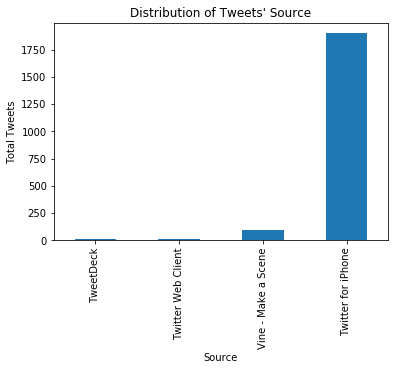

```python
plt.title("Distribution of Tweets' Source")
twitter_archive_master.source.value_counts().sort_values().plot(kind ='bar')
plt.xlabel('Source')
plt.ylabel('Total Tweets');
```

Using histogram reveal that the followers share their funny moments from iphone as a most common source of tweets.

```python
twitter_archive_master.source.value_counts()
```

```
Twitter for iPhone     1900
Vine - Make a Scene      90
Twitter Web Client       12
TweetDeck                11
Name: source, dtype: int64
```

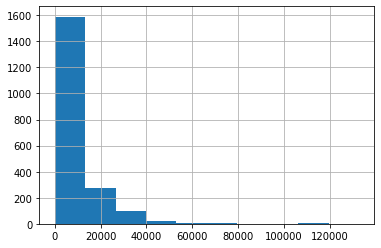

```python
twitter_archive_master.favorite_count.hist();
```

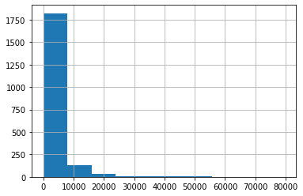

```python
twitter_archive_master.retweet_count.hist();
```

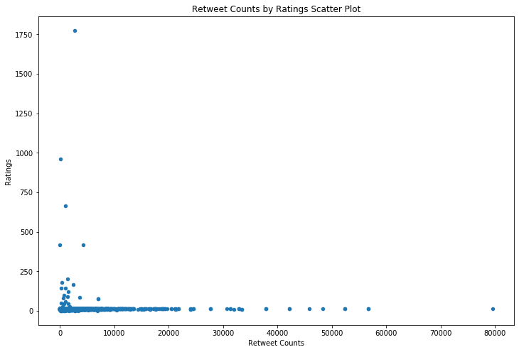

```python
# distribution of ratings according to retweet counts.
twitter_archive_master.plot(x='retweet_count', y='rating_numerator', kind='scatter',figsize=(12,8))
plt.xlabel('Retweet Counts')
plt.ylabel('Ratings')
plt.title('Retweet Counts by Ratings Scatter Plot');
```

This scatterplot reveal that there is no relation between high rating and retweets , Also many tweets have been retweeted more than 20000 times and some more than even 50000 times , generally there is no clear relationship between the ratings and the retweets.

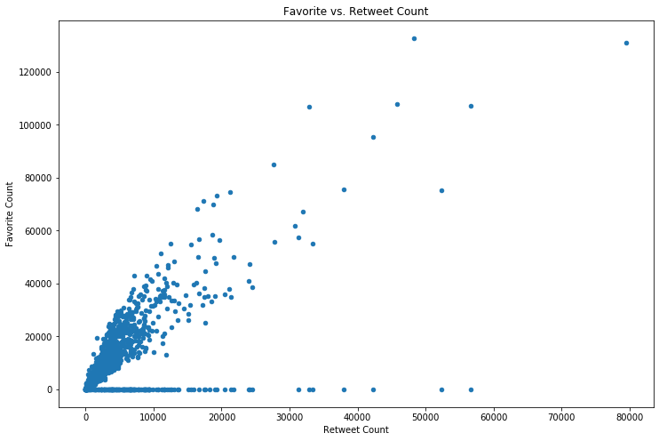

```python
# Plot scatterplot of retweet vs favorite count
twitter_archive_master.plot(x="retweet_count",
           y="favorite_count", kind= 'scatter',figsize=(12,8))
plt.title('Favorite vs. Retweet Count')
plt.xlabel('Retweet Count')
plt.ylabel('Favorite Count');
```

This scatter plot illustrate that there is a strong relation between retweets and favorite count. The increase in favorite leads to an increase in retweets, Positive correlation. The majority of the data falls below 40000 favorites and 20000 retweets.

```python
twitter_archive_master.second_prediction.value_counts()
```

```
Labrador_retriever    100
golden_retriever       91
Cardigan               70
Chihuahua              43
Pomeranian             42
                     ...
bucket                  1
snorkel                 1
mashed_potato           1
spindle                 1
coral_reef              1
Name: second_prediction, Length: 397, dtype: int64
```

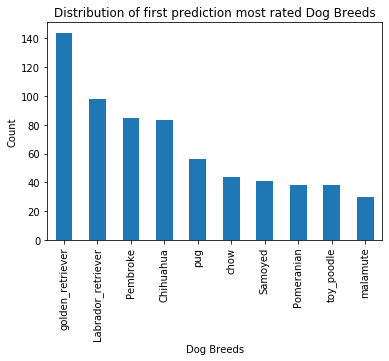

```python
# frequency of  first prediction of dog breeds
twitter_archive_master.first_prediction.value_counts()[:10].plot(kind='bar')
plt.title('Distribution of first prediction most rated Dog Breeds')
plt.xlabel('Dog Breeds')
plt.ylabel('Count');
```

This bar chart reveals the first prediction most common dog rated. It is a golden retriever.

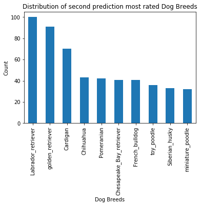

```python
# frequency of  second prediction of dog breeds
twitter_archive_master.second_prediction.value_counts()[:10].plot(kind='bar')
plt.title('Distribution of second prediction most rated Dog Breeds')
plt.xlabel('Dog Breeds')
plt.ylabel('Count');
```

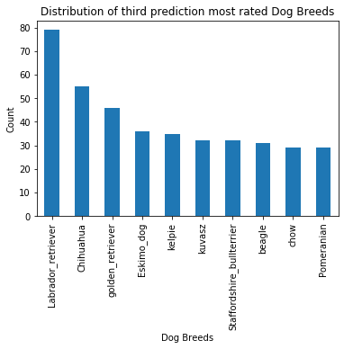

```python
#frequency of third prediction of dog breeds
twitter_archive_master.third_prediction.value_counts()[:10].plot(kind='bar')
plt.title('Distribution of third prediction most rated Dog Breeds')
plt.xlabel('Dog Breeds')
plt.ylabel('Count');
```

```python
samples = twitter_archive_master.query('first_prediction_dog == 1').sample(5)
samples
```

|  | tweet_id | timestamp | source | text | expanded_urls | rating_numerator | rating_denominator | dog_name | month | year | ... | img_num | first_prediction | first_prediction_confident | first_prediction_dog | second_prediction | second_prediction_confident | second_prediction_dog | third_prediction | third_prediction_confident | third_prediction_dog |
| --- | --- | --- | --- | --- | --- | --- | --- | --- | --- | --- | --- | --- | --- | --- | --- | --- | --- | --- | --- | --- | --- |
| 1733 | 677334615166730240 | 2015-12-23 21:37:40+00:00 | Twitter for iPhone | This dog gave up mid jump. 9/10 https://t.co/K... | https://twitter.com/dog_rates/status/677334615... | 9 | 10 | NaN | 12 | 2015 | ... | 1 | kuvasz | 0.451516 | True | golden_retriever | 0.317196 | True | English_setter | 0.132759 | True |
| 1813 | 675145476954566656 | 2015-12-15 14:50:49+00:00 | Twitter for iPhone | What an honor. 3 dogs here. Blond one is clear... | https://twitter.com/dog_rates/status/675145476... | 9 | 10 | NaN | 12 | 2015 | ... | 1 | Irish_water_spaniel | 0.567475 | True | Labrador_retriever | 0.169496 | True | curly-coated_retriever | 0.101518 | True |
| 1992 | 671390180817915904 | 2015-12-04 03:13:46+00:00 | Twitter for iPhone | Striped dog here. Having fun playing on back. ... | https://twitter.com/dog_rates/status/671390180... | 7 | 10 | NaN | 11 | 2015 | ... | 1 | French_bulldog | 0.995026 | True | pug | 0.000932 | True | bull_mastiff | 0.000903 | True |
| 1505 | 688789766343622656 | 2016-01-26 01:21:31+00:00 | Twitter for iPhone | Meet Pubert. He's a Kerplunk Rumplestilt. Cann... | https://twitter.com/dog_rates/status/688789766... | 8 | 10 | Pubert | 1 | 2016 | ... | 1 | golden_retriever | 0.559308 | True | Labrador_retriever | 0.390222 | True | cocker_spaniel | 0.036316 | True |
| 324 | 832369877331693569 | 2017-02-21 17:04:24+00:00 | Twitter for iPhone | This is Charlie. He fell asleep on a heating v... | https://twitter.com/dog_rates/status/832369877... | 11 | 10 | Charlie | 2 | 2017 | ... | 1 | pug | 0.332536 | True | French_bulldog | 0.258124 | True | bull_mastiff | 0.120873 | True |

5 rows × 24 columns

```python
Image(url=samples.jpg_url.iloc[0], width=300, height=300)
```

[figure not shown]

```python
Image(url=samples.jpg_url.iloc[1], width=300, height=300)
```

[figure not shown]

```python
Image(url=samples.jpg_url.iloc[2], width=300, height=300)
```

[figure not shown]

```python
Image(url=samples.jpg_url.iloc[3], width=300, height=300)
```

[figure not shown]

```python
Image(url=samples.jpg_url.iloc[4], width=300, height=300)
```

[figure not shown]

```python
samples_second_prediction = twitter_archive_master.query('second_prediction_dog == 1').sample(5)
samples
```

[output not shown]

5 rows × 24 columns

```python
Image(url=samples_second_prediction.jpg_url.iloc[0], width=300, height=300)
```

[figure not shown]

```python
Image(url=samples_second_prediction.jpg_url.iloc[1], width=300, height=300)
```

[figure not shown]

```python
Image(url=samples_second_prediction.jpg_url.iloc[2], width=300, height=300)
```

[figure not shown]

```python
samples_third_prediction = twitter_archive_master.query('third_prediction_dog == 1').sample(5)
samples
```

[output not shown]

5 rows × 24 columns

```python
Image(url=samples_third_prediction.jpg_url.iloc[0], width=300, height=300)
```

[figure not shown]

```python
Image(url=samples_third_prediction.jpg_url.iloc[1], width=300, height=300)
```

[figure not shown]

```python
Image(url=samples_third_prediction.jpg_url.iloc[2], width=300, height=300)
```

[figure not shown]

# The top retweeted and/or favorite dog

```python
# Top favorite_count
twitter_archive_master.favorite_count.max()
```

```
132810.0
```

```
No. of retweets is : 48265.0,
No. of favorite_count is : 132810.0
```

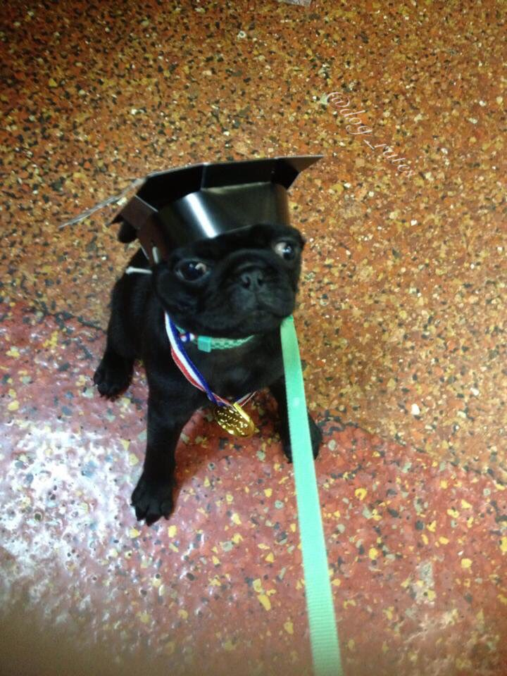

```python
# final winner according to max favorite_count
# get the winner who has the largest favorite_count
max_favorite = twitter_archive_master.favorite_count.max()
winner = twitter_archive_master.query('favorite_count == @max_favorite')

r = requests.get(winner['jpg_url'].item())
#Image(r.content)

# print the final result
print(f"No. of retweets is : {winner['retweet_count'].item()}, \nNo. of favorite_count is : {winner['favorite_count'].item()}")
Image(r.content)
```

```python
# Top retweet_count
twitter_archive_master.retweet_count.max()
```

```
79515.0
```

```
No. of retweets is : 79515.0,
No. of favorite_count is : 131075.0
```

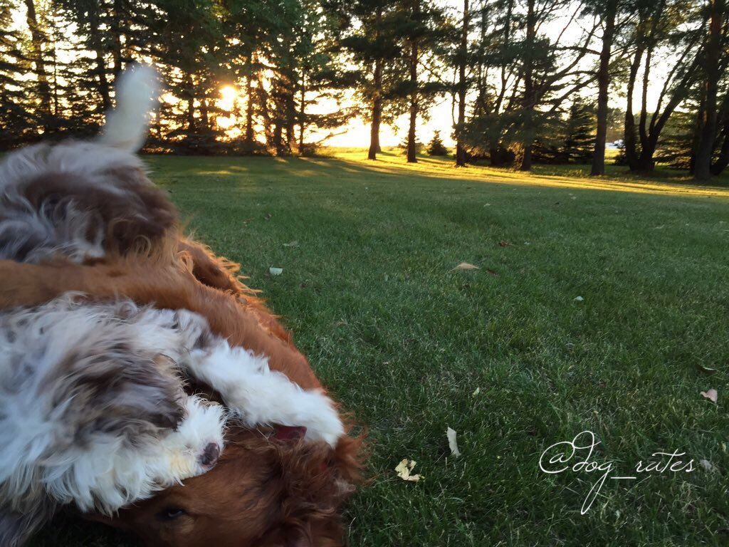

```python
# final winner according to max retweet_count
# get the winner who has the largest retweet_count
max_retweet = twitter_archive_master.retweet_count.max()
winner = twitter_archive_master.query('retweet_count == @max_retweet')
r2 = requests.get(winner['jpg_url'].item())
#Image(r2.content)

# print the final result
print(f"No. of retweets is : {winner['retweet_count'].item()}, \nNo. of favorite_count is : {winner['favorite_count'].item()}")
Image(r2.content)
```